#1. Defining the Question

##a) Specifying the data analytic question `Create a model that will consistently and accurately identify which individuals are most likely to click on ads.`

##b) Defining the metric of success

`The model will be considered a success when it is able to consistently and accurately predict the target variable with an accuracy of 85% - 95%. The range ensures we have a well performing model while also avoiding overfitting.`

##c) Understanding the context `A Kenyan entrepreneur has created an online cryptography course and would want to advertise it on her blog. She currently targets audiences originating from various countries. In the past, she ran ads to advertise a related course on the same blog and collected data in the process. She would now like to employ my services as a Data Science Consultant to help her identify which individuals are most likely to click on her ads.`

##d) Recording the experimental design `The process will entail:`

- Define the question, the metric for success, the context, experimental design taken.
- Read and explore the given dataset.
- Define the appropriateness of the available data to answer the given question.
- Find and deal with outliers, anomalies, and missing data within the dataset.
- Perform univariate and bivariate analysis recording my observations.
- Implement the solution.
- Challenge the solution.
- Follow up questions.

##e) Data Relevance

`The appropriate dataset for this project is one that contains data on the characteristics of the individuals who read the client's blogs.Its appropriateness will be measured against the metrics of success. The following are the descriptions of the columns contained in the dataset:`

- Daily Time Spent on Site: Time (in minutes) that the individual spent on the site
- Age: Individuals’s age in years
- Area Income: Average income of geographical area of the individual
- Daily Internet Usage: Time (in minutes) that the individual spent on the internet
- Ad Topic Line: Headline of the advertisement
- City: The individuals’s city
- Male: Whether or not the individual was male (1=yes, 0=no)
- Country: The individuals’s country
- Timestamp: Date and time the individual visited the site
- Clicked on Ad: Whether or not the individual clicked on an ad (1=yes, 0=no)

`[Advertising dataset](http://bit.ly/IPAdvertisingData)`

#2. Reading the Data

```r
# Loading our data set
advertising <- read.csv('advertising.csv')
```

#3. Checking the data

```r
# Viewing the top 6 entries
head(advertising)
```

```
##   Daily.Time.Spent.on.Site Age Area.Income Daily.Internet.Usage
## 1                    68.95  35    61833.90               256.09
## 2                    80.23  31    68441.85               193.77
## 3                    69.47  26    59785.94               236.50
## 4                    74.15  29    54806.18               245.89
## 5                    68.37  35    73889.99               225.58
## 6                    59.99  23    59761.56               226.74
##                           Ad.Topic.Line           City Male    Country
## 1    Cloned 5thgeneration orchestration    Wrightburgh    0    Tunisia
## 2    Monitored national standardization      West Jodi    1      Nauru
## 3      Organic bottom-line service-desk       Davidton    0 San Marino
## 4 Triple-buffered reciprocal time-frame West Terrifurt    1      Italy
## 5         Robust logistical utilization   South Manuel    0    Iceland
## 6       Sharable client-driven software      Jamieberg    1     Norway
##             Timestamp Clicked.on.Ad
## 1 2016-03-27 00:53:11             0
## 2 2016-04-04 01:39:02             0
## 3 2016-03-13 20:35:42             0
## 4 2016-01-10 02:31:19             0
## 5 2016-06-03 03:36:18             0
## 6 2016-05-19 14:30:17             0
```

```r
#viewing the whole data set
#View(advertising)

#Data types of the columns
str(advertising)
```

```
## 'data.frame':    1000 obs. of  10 variables:
##  $ Daily.Time.Spent.on.Site: num  69 80.2 69.5 74.2 68.4 ...
##  $ Age                     : int  35 31 26 29 35 23 33 48 30 20 ...
##  $ Area.Income             : num  61834 68442 59786 54806 73890 ...
##  $ Daily.Internet.Usage    : num  256 194 236 246 226 ...
##  $ Ad.Topic.Line           : chr  "Cloned 5thgeneration orchestration" "Monitored national standardization" "Organic bottom-line service-desk" "Triple-buffered reciprocal time-frame" ...
##  $ City                    : chr  "Wrightburgh" "West Jodi" "Davidton" "West Terrifurt" ...
##  $ Male                    : int  0 1 0 1 0 1 0 1 1 1 ...
##  $ Country                 : chr  "Tunisia" "Nauru" "San Marino" "Italy" ...
##  $ Timestamp               : chr  "2016-03-27 00:53:11" "2016-04-04 01:39:02" "2016-03-13 20:35:42" "2016-01-10 02:31:19" ...
##  $ Clicked.on.Ad           : int  0 0 0 0 0 0 0 1 0 0 ...
```

```r
#Statistical summary of the data set
summary(advertising)
```

```
##  Daily.Time.Spent.on.Site      Age         Area.Income    Daily.Internet.Usage
##  Min.   :32.60            Min.   :19.00   Min.   :13996   Min.   :104.8
##  1st Qu.:51.36            1st Qu.:29.00   1st Qu.:47032   1st Qu.:138.8
##  Median :68.22            Median :35.00   Median :57012   Median :183.1
##  Mean   :65.00            Mean   :36.01   Mean   :55000   Mean   :180.0
##  3rd Qu.:78.55            3rd Qu.:42.00   3rd Qu.:65471   3rd Qu.:218.8
##  Max.   :91.43            Max.   :61.00   Max.   :79485   Max.   :270.0
##  Ad.Topic.Line          City                Male         Country
##  Length:1000        Length:1000        Min.   :0.000   Length:1000
##  Class :character   Class :character   1st Qu.:0.000   Class :character
##  Mode  :character   Mode  :character   Median :0.000   Mode  :character
##                                        Mean   :0.481
##                                        3rd Qu.:1.000
##                                        Max.   :1.000
##   Timestamp         Clicked.on.Ad
##  Length:1000        Min.   :0.0
##  Class :character   1st Qu.:0.0
##  Mode  :character   Median :0.5
##                     Mean   :0.5
##                     3rd Qu.:1.0
##                     Max.   :1.0
```

```r
#checking the number of entries and attributes
dim(advertising)
```

```
## [1] 1000   10
```

```r
#checking the class of our object
class(advertising)
```

```
## [1] "data.frame"
```

#4. Tidying the data/ Data Cleaning

`*Checking for missing data*`

```r
#Data completeness
#Checking for missing data
colSums(is.na(advertising))
```

```
## Daily.Time.Spent.on.Site                      Age              Area.Income
##                        0                        0                        0
##     Daily.Internet.Usage            Ad.Topic.Line                     City
##                        0                        0                        0
##                     Male                  Country                Timestamp
##                        0                        0                        0
##            Clicked.on.Ad
##                        0
```

`There are no missing values in our data set.`

`*Checking for duplicates*`

```r
#Data consistency

duplicated.rows <- advertising[duplicated(advertising),]
duplicated.rows
```

```
##  [1] Daily.Time.Spent.on.Site Age                      Area.Income
##  [4] Daily.Internet.Usage     Ad.Topic.Line            City
##  [7] Male                     Country                  Timestamp
## [10] Clicked.on.Ad
## <0 rows> (or 0-length row.names)
```

```r
anyDuplicated(advertising)
```

```
## [1] 0
```

`There is no duplicated data in our dataset`

```r
#Changing the male column to gender
names(advertising)[names(advertising) == 'Male'] <- 'Gender'
advertising$Gender <- as.factor(advertising$Gender)
head(advertising)
```

```
##   Daily.Time.Spent.on.Site Age Area.Income Daily.Internet.Usage
## 1                    68.95  35    61833.90               256.09
## 2                    80.23  31    68441.85               193.77
## 3                    69.47  26    59785.94               236.50
## 4                    74.15  29    54806.18               245.89
## 5                    68.37  35    73889.99               225.58
## 6                    59.99  23    59761.56               226.74
##                           Ad.Topic.Line           City Gender    Country
## 1    Cloned 5thgeneration orchestration    Wrightburgh      0    Tunisia
## 2    Monitored national standardization      West Jodi      1      Nauru
## 3      Organic bottom-line service-desk       Davidton      0 San Marino
## 4 Triple-buffered reciprocal time-frame West Terrifurt      1      Italy
## 5         Robust logistical utilization   South Manuel      0    Iceland
## 6       Sharable client-driven software      Jamieberg      1     Norway
##             Timestamp Clicked.on.Ad
## 1 2016-03-27 00:53:11             0
## 2 2016-04-04 01:39:02             0
## 3 2016-03-13 20:35:42             0
## 4 2016-01-10 02:31:19             0
## 5 2016-06-03 03:36:18             0
## 6 2016-05-19 14:30:17             0
```

```r
#covert clicked on ad column to factor

advertising$Clicked.on.Ad <- as.factor(advertising$Clicked.on.Ad)
str(advertising)
```

```
## 'data.frame':    1000 obs. of  10 variables:
##  $ Daily.Time.Spent.on.Site: num  69 80.2 69.5 74.2 68.4 ...
##  $ Age                     : int  35 31 26 29 35 23 33 48 30 20 ...
##  $ Area.Income             : num  61834 68442 59786 54806 73890 ...
##  $ Daily.Internet.Usage    : num  256 194 236 246 226 ...
##  $ Ad.Topic.Line           : chr  "Cloned 5thgeneration orchestration" "Monitored national standardization" "Organic bottom-line service-desk" "Triple-buffered reciprocal time-frame" ...
##  $ City                    : chr  "Wrightburgh" "West Jodi" "Davidton" "West Terrifurt" ...
##  $ Gender                  : Factor w/ 2 levels "0","1": 1 2 1 2 1 2 1 2 2 2 ...
##  $ Country                 : chr  "Tunisia" "Nauru" "San Marino" "Italy" ...
##  $ Timestamp               : chr  "2016-03-27 00:53:11" "2016-04-04 01:39:02" "2016-03-13 20:35:42" "2016-01-10 02:31:19" ...
##  $ Clicked.on.Ad           : Factor w/ 2 levels "0","1": 1 1 1 1 1 1 1 2 1 1 ...
```

```r
#converting timestamp column to datetime
library('lubridate')
library('dplyr')
advertising %>%
  mutate_all(type.convert)%>%
  mutate_if(is.factor, as.character)%>%
  mutate(Timestamp= as_datetime(Timestamp, tz=Sys.timezone()))
```

[output not shown]

[output cut: 4990 more lines]

```r
#extracting the year, month and day from the timestamp column
advertising$Year <- format(as.POSIXct(advertising$Timestamp, format='%Y-%m-%d %H:%M:%S'), '%Y')
advertising$Month <- format(as.POSIXct(advertising$Timestamp, format= '%Y-%m-%d %H:%M:%S'), '%m')
advertising$Day <- format(as.POSIXct(advertising$Timestamp, format= '%Y-%m-%d %H:%M:%S'), '%d')
advertising$Hour <- format(as.POSIXct(advertising$Timestamp, format= '%Y-%m-%d %H:%M:%S'), '%H')

head(advertising)
```

```
##   Daily.Time.Spent.on.Site Age Area.Income Daily.Internet.Usage
## 1                    68.95  35    61833.90               256.09
## 2                    80.23  31    68441.85               193.77
## 3                    69.47  26    59785.94               236.50
## 4                    74.15  29    54806.18               245.89
## 5                    68.37  35    73889.99               225.58
## 6                    59.99  23    59761.56               226.74
##                           Ad.Topic.Line           City Gender    Country
## 1    Cloned 5thgeneration orchestration    Wrightburgh      0    Tunisia
## 2    Monitored national standardization      West Jodi      1      Nauru
## 3      Organic bottom-line service-desk       Davidton      0 San Marino
## 4 Triple-buffered reciprocal time-frame West Terrifurt      1      Italy
## 5         Robust logistical utilization   South Manuel      0    Iceland
## 6       Sharable client-driven software      Jamieberg      1     Norway
##             Timestamp Clicked.on.Ad Year Month Day Hour
## 1 2016-03-27 00:53:11             0 2016    03  27   00
## 2 2016-04-04 01:39:02             0 2016    04  04   01
## 3 2016-03-13 20:35:42             0 2016    03  13   20
## 4 2016-01-10 02:31:19             0 2016    01  10   02
## 5 2016-06-03 03:36:18             0 2016    06  03   03
## 6 2016-05-19 14:30:17             0 2016    05  19   14
```

```r
colSums(is.na(advertising))
```

```
## Daily.Time.Spent.on.Site                      Age              Area.Income
##                        0                        0                        0
##     Daily.Internet.Usage            Ad.Topic.Line                     City
##                        0                        0                        0
##                   Gender                  Country                Timestamp
##                        0                        0                        0
##            Clicked.on.Ad                     Year                    Month
##                        0                        0                        0
##                      Day                     Hour
##                        0                        0
```

```r
#drop the timestamp column
advertising$Timestamp <-NULL
head(advertising)
```

```
##   Daily.Time.Spent.on.Site Age Area.Income Daily.Internet.Usage
## 1                    68.95  35    61833.90               256.09
## 2                    80.23  31    68441.85               193.77
## 3                    69.47  26    59785.94               236.50
## 4                    74.15  29    54806.18               245.89
## 5                    68.37  35    73889.99               225.58
## 6                    59.99  23    59761.56               226.74
##                           Ad.Topic.Line           City Gender    Country
## 1    Cloned 5thgeneration orchestration    Wrightburgh      0    Tunisia
## 2    Monitored national standardization      West Jodi      1      Nauru
## 3      Organic bottom-line service-desk       Davidton      0 San Marino
## 4 Triple-buffered reciprocal time-frame West Terrifurt      1      Italy
## 5         Robust logistical utilization   South Manuel      0    Iceland
## 6       Sharable client-driven software      Jamieberg      1     Norway
##   Clicked.on.Ad Year Month Day Hour
## 1             0 2016    03  27   00
## 2             0 2016    04  04   01
## 3             0 2016    03  13   20
## 4             0 2016    01  10   02
## 5             0 2016    06  03   03
## 6             0 2016    05  19   14
```

```r
#convert the year, month, day, hour columns to factor
advertising$Year <- as.factor(advertising$Year)
advertising$Month <- as.factor(advertising$Month)
advertising$Day <- as.factor(advertising$Day)
advertising$Hour <- as.factor(advertising$Hour)
str(advertising)
```

```
## 'data.frame':    1000 obs. of  13 variables:
##  $ Daily.Time.Spent.on.Site: num  69 80.2 69.5 74.2 68.4 ...
##  $ Age                     : int  35 31 26 29 35 23 33 48 30 20 ...
##  $ Area.Income             : num  61834 68442 59786 54806 73890 ...
##  $ Daily.Internet.Usage    : num  256 194 236 246 226 ...
##  $ Ad.Topic.Line           : chr  "Cloned 5thgeneration orchestration" "Monitored national standardization" "Organic bottom-line service-desk" "Triple-buffered reciprocal time-frame" ...
##  $ City                    : chr  "Wrightburgh" "West Jodi" "Davidton" "West Terrifurt" ...
##  $ Gender                  : Factor w/ 2 levels "0","1": 1 2 1 2 1 2 1 2 2 2 ...
##  $ Country                 : chr  "Tunisia" "Nauru" "San Marino" "Italy" ...
##  $ Clicked.on.Ad           : Factor w/ 2 levels "0","1": 1 1 1 1 1 1 1 2 1 1 ...
##  $ Year                    : Factor w/ 1 level "2016": 1 1 1 1 1 1 1 1 1 1 ...
##  $ Month                   : Factor w/ 7 levels "01","02","03",..: 3 4 3 1 6 5 1 3 4 7 ...
##  $ Day                     : Factor w/ 31 levels "01","02","03",..: 27 4 13 10 3 19 28 7 18 11 ...
##  $ Hour                    : Factor w/ 24 levels "00","01","02",..: 1 2 21 3 4 15 21 2 10 2 ...
```

`*Checking for outliers*`

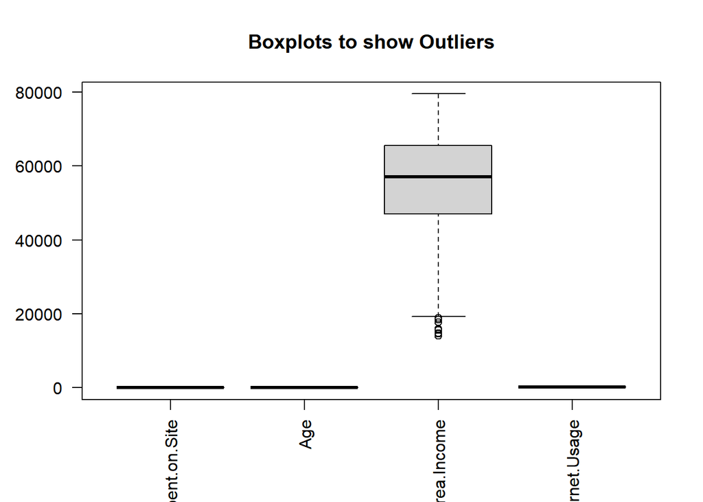

```r
#Create a list of numeric columns
num.cols <- list(advertising$Daily.Time.Spent.on.Site,advertising$Age,
advertising$Area.Income,advertising$Daily.Internet.Usage)

#Checking for outliers
boxplot(num.cols, names=c('Daily.Time.Spent.on.Site', 'Age', 'Area.Income', 'Daily.Internet.Usage'), main='Boxplots to show Outliers', las=2)
```

```r
#Listing the outliers
boxplot.stats(advertising$Area.Income)$out
```

```
## [1] 17709.98 18819.34 15598.29 15879.10 14548.06 13996.50 14775.50 18368.57
```

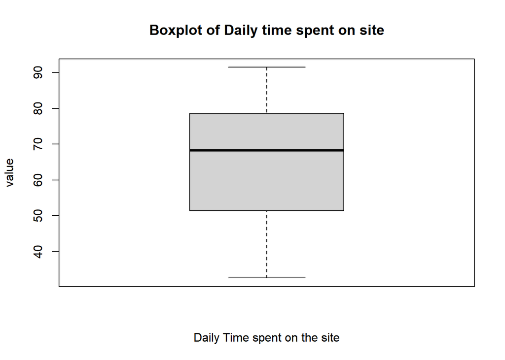

```r
#Plotting boxplots of individual columns

boxplot(advertising$Daily.Time.Spent.on.Site, main='Boxplot of Daily time spent on site', xlab='Daily Time spent on the site', ylab='value')
```

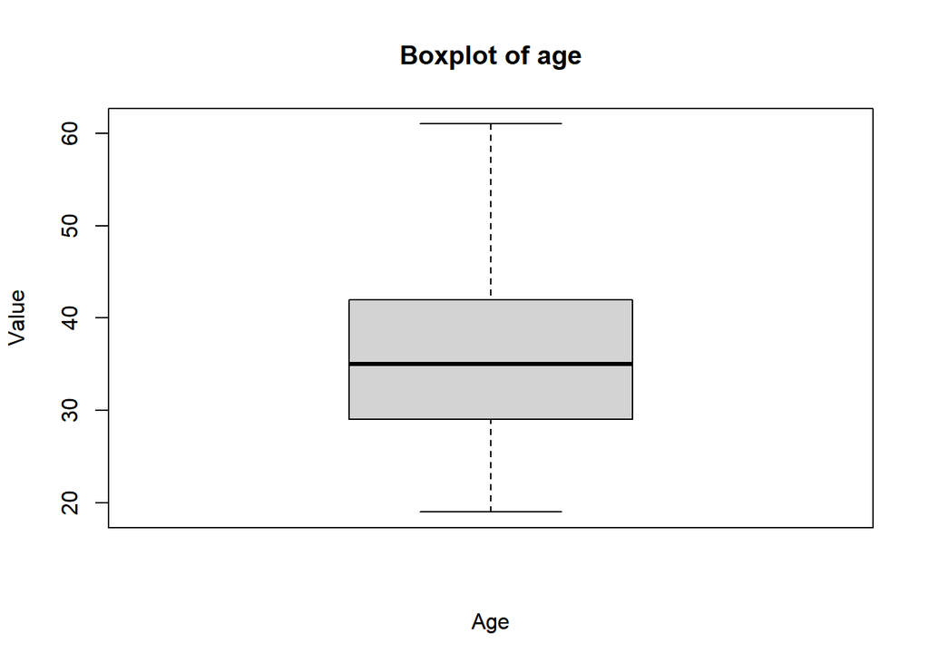

```r
boxplot(advertising$Age, main='Boxplot of age', xlab='Age', ylab='Value')
```

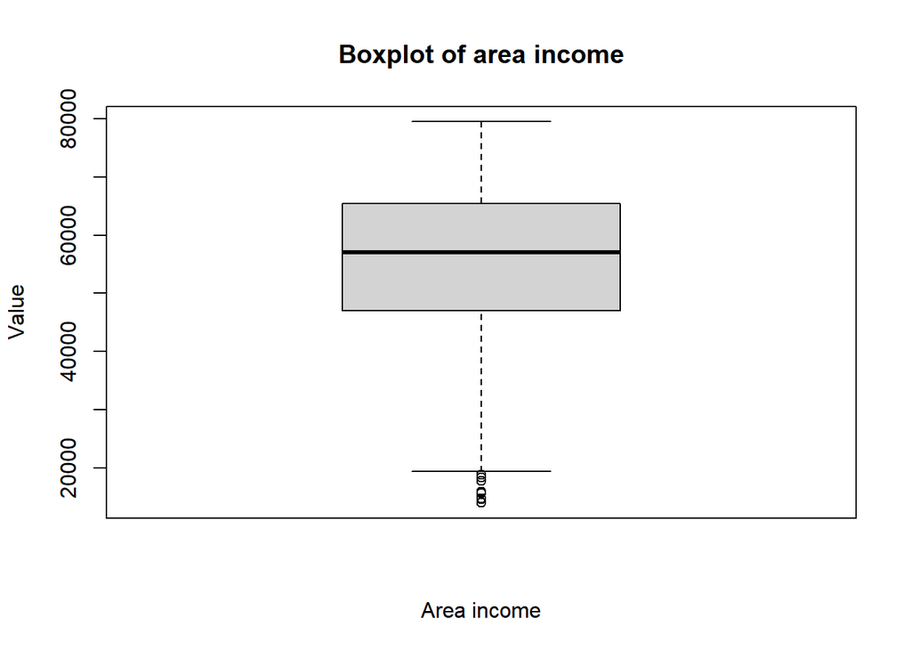

```r
boxplot(advertising$Area.Income, main='Boxplot of area income', xlab='Area income', ylab='Value')
```

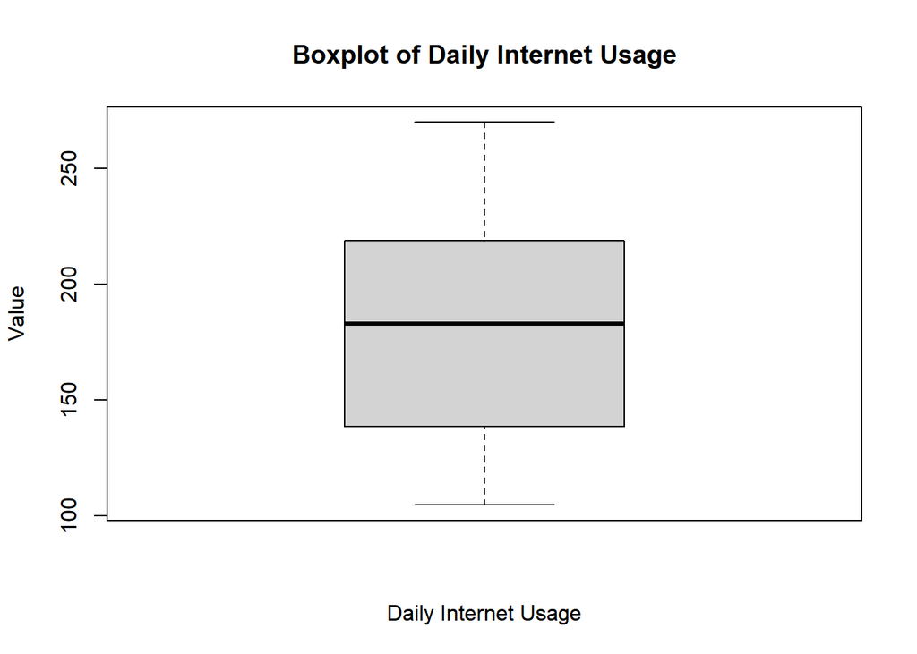

```r
boxplot(advertising$Daily.Internet.Usage, main='Boxplot of Daily Internet Usage', xlab='Daily Internet Usage', ylab='Value')
```

`The outliers in area income might be due to low numbers of ad clicks so no need to remove them.`

#5 Univariate Exploratory Data Analysis

## Measures of Central Tendancy

```r
#Finding the mean
mean <- colMeans(advertising[sapply(advertising, is.numeric)])
print(mean)
```

```
## Daily.Time.Spent.on.Site                      Age              Area.Income
##                  65.0002                  36.0090               55000.0001
##     Daily.Internet.Usage
##                 180.0001
```

```r
#Finding the median
#loading the tidyverse and robustbase(for the colMedians function) libraries
library(robustbase)
library(tidyverse)
median <- advertising%>%
  select_if(is.numeric) %>%
  as.matrix()%>%
  colMedians()
print(median)
```

```
## Daily.Time.Spent.on.Site                      Age              Area.Income
##                   68.215                   35.000                57012.300
##     Daily.Internet.Usage
##                  183.130
```

```r
#Finding the mode
#mode <- function(x) {
 # uniq_data <- unique(x)
  #map_data <- match(x, uniq_data)
  #tab_data <- tabulate(map_data)
 # max_val <- max(tab_data)
  #uniq_data[tab_data == max_val]
#}
mode <- function(v) {
   uniqv <- unique(v)
   uniqv[which.max(tabulate(match(v, uniqv)))]
}


mode(advertising$Daily.Time.Spent.on.Site)
```

```
## [1] 62.26
```

```r
mode(advertising$Age)
```

```
## [1] 31
```

```r
mode(advertising$Area.Income)
```

```
## [1] 61833.9
```

```r
mode(advertising$Daily.Internet.Usage)
```

```
## [1] 167.22
```

```r
mode(advertising$Ad.Topic.Line)
```

```
## [1] "Cloned 5thgeneration orchestration"
```

```r
mode(advertising$City)
```

```
## [1] "Lisamouth"
```

```r
mode(advertising$Gender)
```

```
## [1] 0
## Levels: 0 1
```

```r
mode(advertising$Country)
```

```
## [1] "Czech Republic"
```

```r
mode(advertising$Year)
```

```
## [1] 2016
## Levels: 2016
```

```r
mode(advertising$Month)
```

```
## [1] 02
## Levels: 01 02 03 04 05 06 07
```

```r
mode(advertising$Day)
```

```
## [1] 03
## 31 Levels: 01 02 03 04 05 06 07 08 09 10 11 12 13 14 15 16 17 18 19 20 ... 31
```

```r
mode(advertising$Hour)
```

```
## [1] 07
## 24 Levels: 00 01 02 03 04 05 06 07 08 09 10 11 12 13 14 15 16 17 18 19 ... 23
```

```r
mode(advertising$Clicked.on.Ad)
```

```
## [1] 0
## Levels: 0 1
```

[output not shown]

## Measures of Dispersion

```r
#Finding the minimum
num.cols <- list(advertising$Daily.Time.Spent.on.Site,advertising$Age,
advertising$Area.Income,advertising$Daily.Internet.Usage)

min(advertising$Daily.Time.Spent.on.Site)
```

```
## [1] 32.6
```

```r
min(advertising$Age)
```

```
## [1] 19
```

```r
min(advertising$Area.Income)
```

```
## [1] 13996.5
```

```r
min(advertising$Daily.Internet.Usage)
```

```
## [1] 104.78
```

```r
#Finding the maximum
max(advertising$Daily.Time.Spent.on.Site)
```

```
## [1] 91.43
```

```r
max(advertising$Age)
```

```
## [1] 61
```

```r
max(advertising$Area.Income)
```

```
## [1] 79484.8
```

```r
max(advertising$Daily.Internet.Usage)
```

```
## [1] 269.96
```

```r
#Finding the Range
range(advertising$Daily.Time.Spent.on.Site)
```

```
## [1] 32.60 91.43
```

```r
range(advertising$Age)
```

```
## [1] 19 61
```

```r
range(advertising$Area.Income)
```

```
## [1] 13996.5 79484.8
```

```r
range(advertising$Daily.Internet.Usage)
```

```
## [1] 104.78 269.96
```

```r
#Finding the quantiles
quantile(advertising$Daily.Time.Spent.on.Site)
```

```
##      0%     25%     50%     75%    100%
## 32.6000 51.3600 68.2150 78.5475 91.4300
```

```r
quantile(advertising$Age)
```

```
##   0%  25%  50%  75% 100%
##   19   29   35   42   61
```

```r
quantile(advertising$Area.Income)
```

```
##       0%      25%      50%      75%     100%
## 13996.50 47031.80 57012.30 65470.64 79484.80
```

```r
quantile(advertising$Daily.Internet.Usage)
```

```
##       0%      25%      50%      75%     100%
## 104.7800 138.8300 183.1300 218.7925 269.9600
```

```r
#Finding the variance
var(advertising$Daily.Time.Spent.on.Site)
```

```
## [1] 251.3371
```

```r
var(advertising$Age)
```

```
## [1] 77.18611
```

```r
var(advertising$Area.Income)
```

```
## [1] 179952406
```

```r
#Finding the Standard Deviation
sd(advertising$Daily.Time.Spent.on.Site)
```

```
## [1] 15.85361
```

```r
sd(advertising$Age)
```

```
## [1] 8.785562
```

```r
sd(advertising$Area.Income)
```

```
## [1] 13414.63
```

```r
sd(advertising$Daily.Internet.Usage)
```

```
## [1] 43.90234
```

```r
#Finding skewness
library(e1071)
skewness(advertising$Daily.Time.Spent.on.Site)
```

```
## [1] -0.370646
```

```r
skewness(advertising$Age)
```

```
## [1] 0.4777052
```

```r
skewness(advertising$Area.Income)
```

```
## [1] -0.6484229
```

```r
skewness(advertising$Daily.Internet.Usage)
```

```
## [1] -0.03343681
```

```r
#Finding Kurtosis
library(e1071)
kurtosis(advertising$Daily.Time.Spent.on.Site)
```

```
## [1] -1.099864
```

```r
kurtosis(advertising$Age)
```

```
## [1] -0.4097066
```

```r
kurtosis(advertising$Area.Income)
```

```
## [1] -0.1110924
```

```r
kurtosis(advertising$Daily.Internet.Usage)
```

```
## [1] -1.275752
```

## Univariate Data analysis Graphicals

### categorical columns

```r
#Creating a frequency table for city
city <- advertising$City
freq_city <- table(city)
freq_city
```

```
## city
##               Adamsbury                Adamside               Adamsstad
##                       1                       1                       1
##                Alanview           Alexanderfurt           Alexanderview
##                       1                       1                       1
##           Alexandrafort              Alexisland              Aliciatown
##                       1                       1                       1
##            Alvaradoport             Alvarezland              Amandafort
##                       1                       1                       1
##             Amandahaven              Amandaland                 Amyfurt
##                       1                       1                       1
##                Amyhaven         Andersonchester            Andersonfurt
##                       1                       1                       1
##             Andersonton           Andrewborough             Andrewmouth
##                       1                       1                       1
##              Angelhaven             Anthonyfurt           Ashleychester
##                       1                       1                       1
##             Ashleymouth           Austinborough              Austinland
##                       1                       1                       1
##              Bakerhaven             Barbershire                 Beckton
##                       1                       1                       1
##         Benjaminchester              Bernardton               Bethburgh
##                       2                       1                       1
##               Birdshire            Blairborough              Blairville
##                       1                       1                       1
##             Blevinstown               Bowenview               Boyerberg
##                       1                       1                       1
##          Bradleyborough            Bradleyburgh             Bradleyside
##                       1                       1                       1
##         Bradshawborough               Bradyfurt              Brandiland
##                       1                       1                       1
##             Brandonbury             Brandonstad             Brandymouth
##                       1                       1                       1
##             Brendaburgh           Brendachester              Brianabury
##                       1                       1                       1
##               Brianfurt               Brianland         Brittanyborough
##                       1                       1                       1
##               Brownbury               Brownport                Brownton
##                       1                       1                       1
##               Browntown               Brownview              Bruceburgh
```

[output cut: 592 more lines]

```
##                       1                       1                       1
##             Whitneyfort              Wilcoxport            Williammouth
##                       1                       1                       1
##             Williamport         Williamsborough            Williamsfort
##                       1                       1                       1
##           Williamsmouth            Williamsport            Williamsside
##                       1                       3                       1
##             Williamstad             Wilsonburgh             Wintersfort
##                       1                       1                       1
##                Wongland             Wrightburgh              Wrightview
##                       1                       2                       1
##                Yangside              Youngburgh               Youngfort
##                       1                       1                       1
##                   Yuton             Zacharystad              Zacharyton
##                       1                       1                       1
```

```r
#Creating a frequency table for country
country <- advertising$Country
freq_country <- table(country)
freq_country
```

```
## country
##                                         Afghanistan
##                                                   8
##                                             Albania
##                                                   7
##                                             Algeria
##                                                   6
##                                      American Samoa
##                                                   5
##                                             Andorra
##                                                   2
##                                              Angola
##                                                   4
##                                            Anguilla
##                                                   6
##        Antarctica (the territory South of 60 deg S)
##                                                   3
##                                 Antigua and Barbuda
##                                                   5
##                                           Argentina
##                                                   2
##                                             Armenia
##                                                   3
##                                               Aruba
##                                                   1
##                                           Australia
##                                                   8
##                                             Austria
##                                                   5
##                                          Azerbaijan
##                                                   3
##                                             Bahamas
##                                                   7
##                                             Bahrain
##                                                   5
##                                          Bangladesh
##                                                   4
##                                            Barbados
##                                                   5
##                                             Belarus
```

[output cut: 420 more lines]

```
##                                                   6
##                                           Venezuela
##                                                   7
##                                             Vietnam
##                                                   3
##                                   Wallis and Futuna
##                                                   4
##                                      Western Sahara
##                                                   7
##                                               Yemen
##                                                   3
##                                              Zambia
##                                                   4
##                                            Zimbabwe
##                                                   6
```

```r
#Frequency table of clicked on ad
Clicked.on.Ad_freq <- table(advertising$Clicked.on.Ad)
Clicked.on.Ad_freq
```

```
##
##   0   1
## 500 500
```

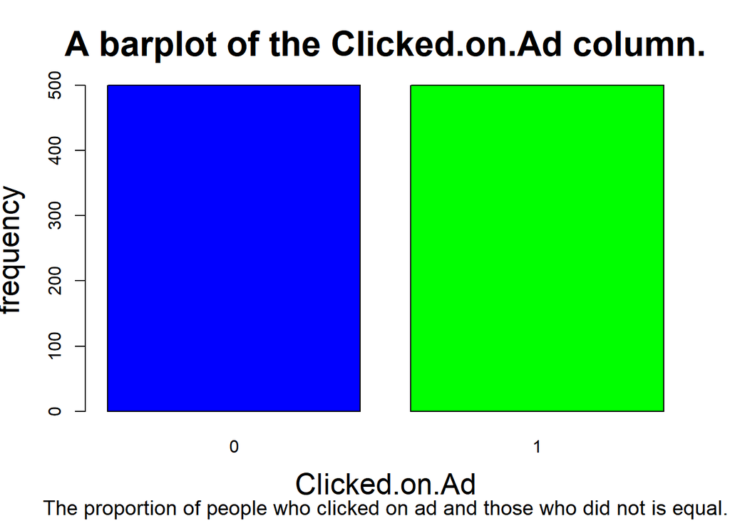

```r
#Bar graph to show frequency distribution of clicked on ad
options(repr.plot.width = 10, repr.plot.height = 10)
barplot(c(Clicked.on.Ad_freq), main="A barplot of the Clicked.on.Ad column.",
        xlab="Clicked.on.Ad",
        ylab="frequency",
        sub="The proportion of people who clicked on ad and those who did not is equal.",
        cex.main=2, cex.lab=1.7,cex.sub=1.2,
        col=c("blue","green"))
```

```r
#Frequency table of gender
gender_freq <- table(advertising$Gender)
gender_freq
```

```
##
##   0   1
## 519 481
```

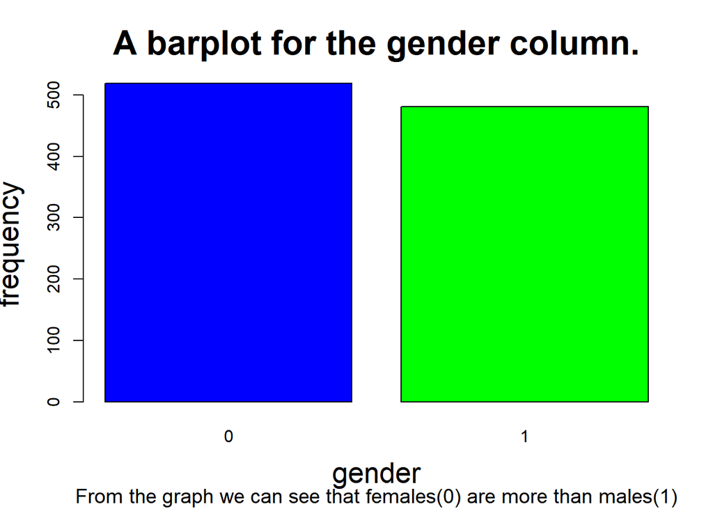

```r
#Bar graph to show frequency distribution of gender
options(repr.plot.width = 10, repr.plot.height = 10)
barplot(c(gender_freq), main="A barplot for the gender column.",
        xlab="gender",
        ylab="frequency",
        sub="From the graph we can see that females(0) are more than males(1)",
        cex.main=2, cex.lab=1.7,cex.sub=1.2,
        width=c(30,30),
        col=c("blue","green"))
```

```r
#Frequency table for month
sort(table(advertising$Month), decreasing = TRUE)[1:5]
```

```
##
##  02  03  01  04  05
## 160 156 147 147 147
```

```r
#Frequency table for day
sort(table(advertising$Day), decreasing = TRUE)[1:5]
```

```
##
## 03 17 15 10 04
## 46 42 41 37 36
```

```r
#Frequency table for hour
sort(table(advertising$Hour), decreasing = TRUE)[1:5]
```

```
##
## 07 20 09 21 00
## 54 50 49 48 45
```

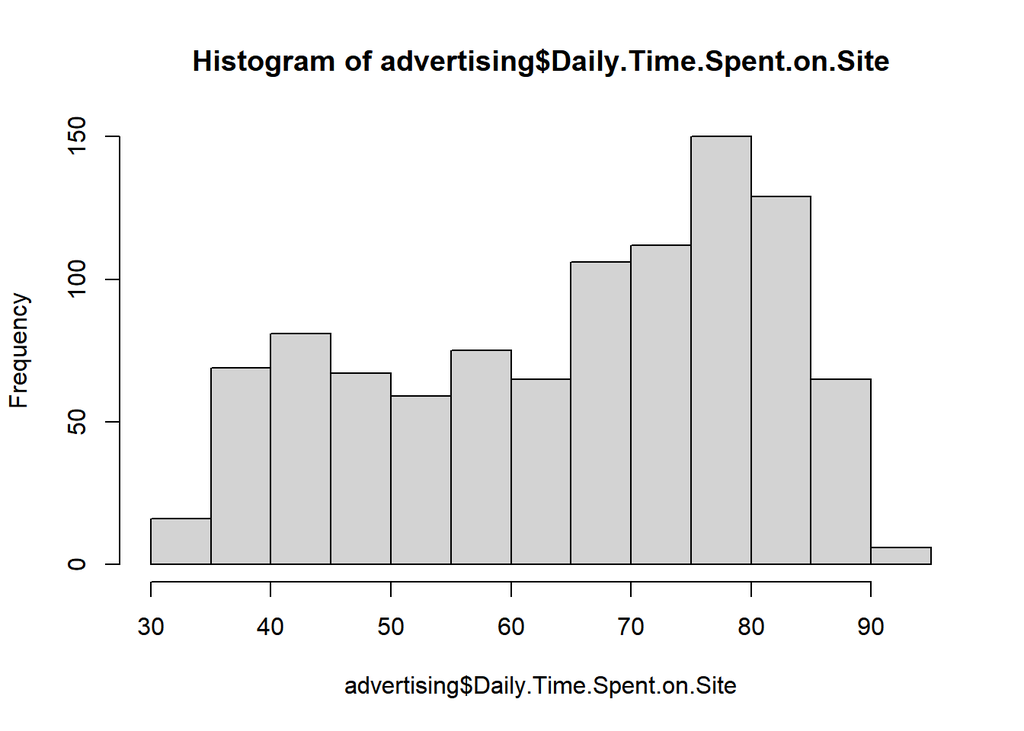

```r
#Creating a histogram for daily time spent on site
hist(advertising$Daily.Time.Spent.on.Site)
```

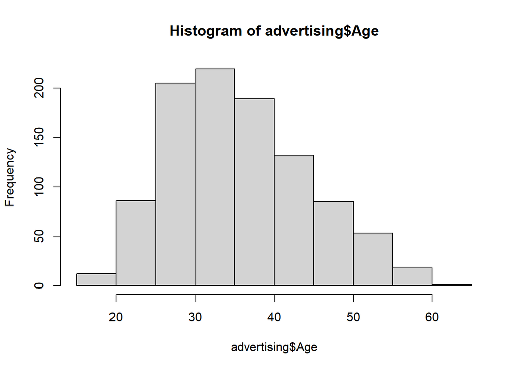

```r
#Creating a histogram for age
hist(advertising$Age)
```

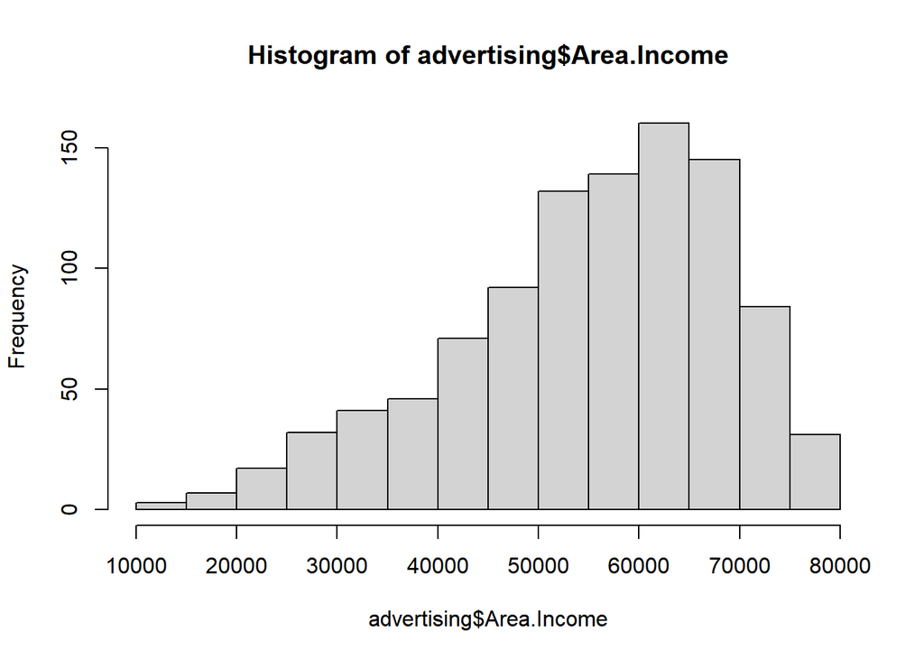

```r
#Creating a histogram for Area Income
hist(advertising$Area.Income)
```

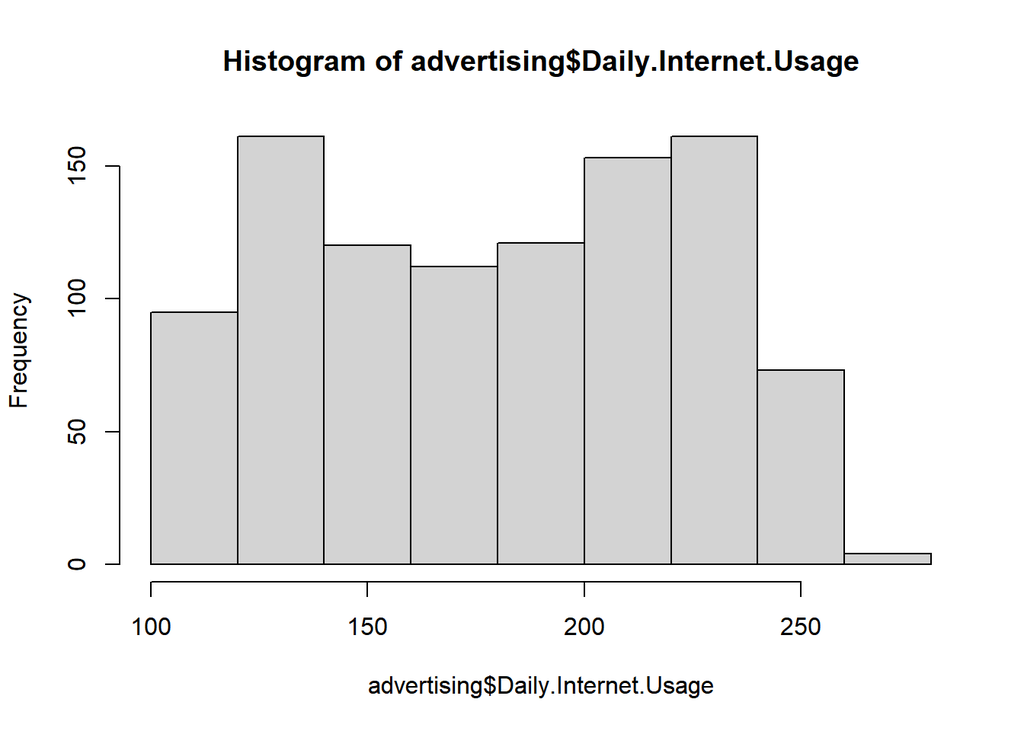

```r
#Creating a histogram of daily internet usage
hist(advertising$Daily.Internet.Usage)
```

### Observations from Univariate Analysis

- Most people in the dataset are 31years.
- The highest frequency of area income is 61833.
- Females are more than males but not with a big margin.
- Those who clicked on the ad are equal to those that did not.
- Highest daily internet usage is 167.22.
- The most frequent time spent on site is 62.26
- Most of the data collected is from Czech Republic
- Lisamouth is the most occuring city within the dataset
- All the data was collected in 2016
- February is the most occuring month
- 07:00am appears the time when most ad clicks happen.
- 3rd day of the month is the most prevalent

#6. Bivariate and Multivariate Data Analysis

```r
#Finding the covariance
cov <- cov(advertising[, unlist(lapply(advertising, is.numeric))])
round(cov, 3)
```

```
##                          Daily.Time.Spent.on.Site        Age  Area.Income
## Daily.Time.Spent.on.Site                  251.337    -46.174     66130.81
## Age                                       -46.174     77.186    -21520.93
## Area.Income                             66130.811 -21520.926 179952405.95
## Daily.Internet.Usage                      360.992   -141.635    198762.53
##                          Daily.Internet.Usage
## Daily.Time.Spent.on.Site              360.992
## Age                                  -141.635
## Area.Income                        198762.532
## Daily.Internet.Usage                 1927.415
```

```r
#Finding the correlation
cor <- cor(advertising[, unlist(lapply(advertising, is.numeric))])
round(cor, 3)
```

```
##                          Daily.Time.Spent.on.Site    Age Area.Income
## Daily.Time.Spent.on.Site                    1.000 -0.332       0.311
## Age                                        -0.332  1.000      -0.183
## Area.Income                                 0.311 -0.183       1.000
## Daily.Internet.Usage                        0.519 -0.367       0.337
##                          Daily.Internet.Usage
## Daily.Time.Spent.on.Site                0.519
## Age                                    -0.367
## Area.Income                             0.337
## Daily.Internet.Usage                    1.000
```

```r
#selecting Clicked.on.Ad data that had 1
clicked <- advertising[advertising$Clicked.on.Ad == 1,]
head(clicked)
```

```
##    Daily.Time.Spent.on.Site Age Area.Income Daily.Internet.Usage
## 8                     66.00  48    24593.33               131.76
## 11                    47.64  49    45632.51               122.02
## 13                    69.57  48    51636.92               113.12
## 15                    42.95  33    30976.00               143.56
## 16                    63.45  23    52182.23               140.64
## 17                    55.39  37    23936.86               129.41
##                            Ad.Topic.Line             City Gender
## 8               Reactive local challenge Port Jefferybury      1
## 11        Centralized neutral neural-net  West Brandonton      0
## 13 Centralized content-based focus group   West Katiefurt      1
## 15         Grass-roots coherent extranet     West William      0
## 16    Persistent demand-driven interface   New Travistown      1
## 17    Customizable multi-tasking website   West Dylanberg      0
##                  Country Clicked.on.Ad Year Month Day Hour
## 8              Australia             1 2016    03  07   01
## 11                 Qatar             1 2016    03  16   20
## 13                 Egypt             1 2016    06  03   01
## 15              Barbados             1 2016    03  24   09
## 16                 Spain             1 2016    03  09   03
## 17 Palestinian Territory             1 2016    01  30   19
```

```r
dim(clicked)
```

```
## [1] 500  13
```

```r
#comparison between gender and clicked on data

gender_frequency <- table(clicked$Gender)
gender_frequency
```

```
##
##   0   1
## 269 231
```

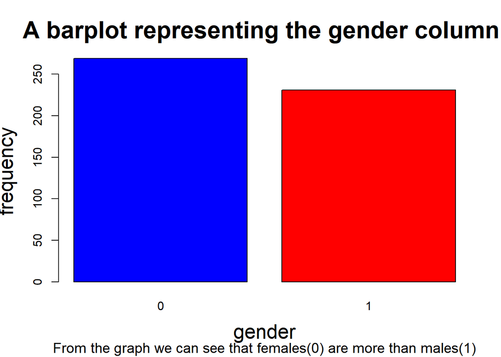

```r
#plotting bar chart of gender column
options(repr.plot.width = 10, repr.plot.height = 10)
barplot(c(gender_frequency), main="A barplot representing the gender column.",
        xlab="gender",
        ylab="frequency",
        sub="From the graph we can see that females(0) are more than males(1)",
        cex.main=2, cex.lab=1.7,cex.sub=1.2,
        width=c(30,30),
        col=c("blue","red"))
```

```r
#comparison of month and clicked on ad

month_frequency <- table(clicked$Month)
month_frequency
```

```
##
## 01 02 03 04 05 06 07
## 69 83 74 74 79 71 50
```

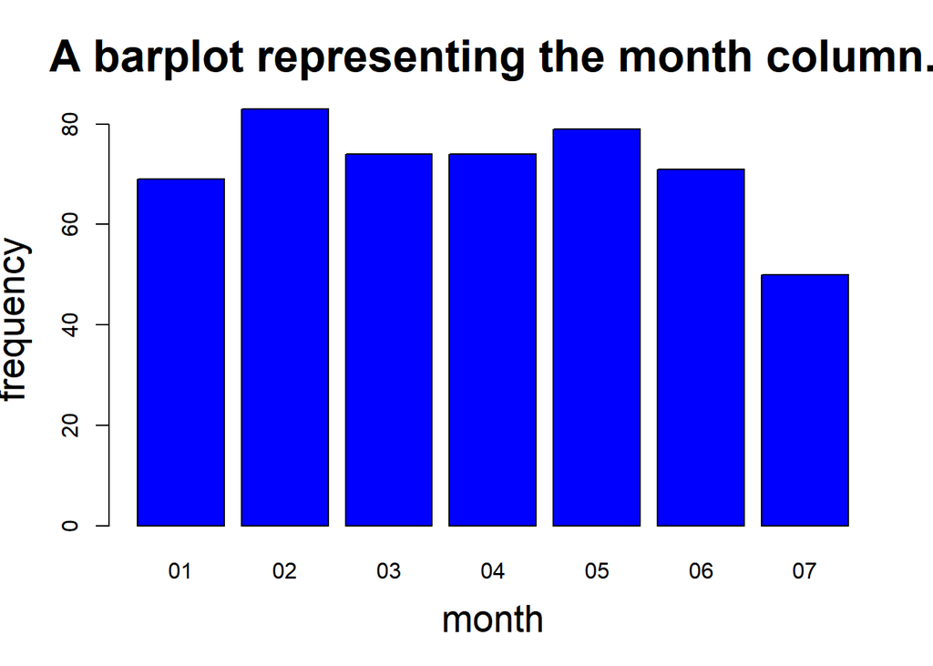

```r
#plotting bar chart of gender column
options(repr.plot.width = 10, repr.plot.height = 10)
barplot(c(month_frequency), main="A barplot representing the month column.",
        xlab="month",
        ylab="frequency",
        cex.main=2, cex.lab=1.7,cex.sub=1.2,
        width=c(30,30),
        col=c("blue"))
```

```r
#comparison of day and clicked on ad
sort(table(clicked$Day), decreasing = TRUE)[1:5]
```

```
##
## 03 23 14 09 12
## 26 22 21 20 20
```

```r
#comparison of hour and clicked on ad
sort(table(clicked$Hour), decreasing = TRUE)[1:5]
```

```
##
## 09 00 07 18 11
## 28 26 26 25 24
```

```r
#comparison of area income and clicked on ad
sort(table(clicked$Area.Income), decreasing = TRUE)[1:5]
```

```
##
##  13996.5 14548.06  14775.5 15598.29  15879.1
##        1        1        1        1        1
```

```r
#comparison of age and clicked on ad
sort(table(clicked$Age), decreasing = TRUE)[1:5]
```

```
##
## 45 36 38 41 42
## 27 25 25 22 20
```

```r
#comparison of country and clicked on ad
sort(table(clicked$Country), decreasing = TRUE)[1:5]
```

```
##
##     Australia      Ethiopia        Turkey       Liberia Liechtenstein
##             7             7             7             6             6
```

```r
#comparison of city and clicked on ad
sort(table(clicked$City), decreasing = TRUE)[1:5]
```

```
##
##   Lake David   Lake James    Lisamouth Michelleside   Millerbury
##            2            2            2            2            2
```

```r
#comparison of daily time spent on site and clicked on ad
sort(table(clicked$Daily.Time.Spent.on.Site), decreasing = TRUE)[1:5]
```

```
##
## 75.55  32.6 35.49 35.66 35.98
##     3     2     2     2     2
```

## Bivariate and Multivariate Graphicals

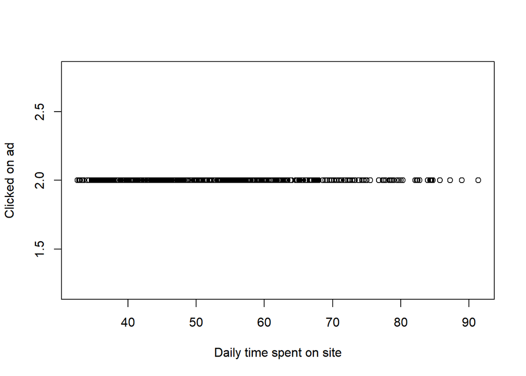

```r
#Plotting a scatterplot of daily time spent on site and clicked on ad
#num.cols <- list(advertising$Daily.Time.Spent.on.Site,advertising$Age,
#advertising$Area.Income,advertising$Daily.Internet.Usage)
daily.time.spent.on.site <- clicked$Daily.Time.Spent.on.Site
clicked.on.Ad <- clicked$Clicked.on.Ad
plot(daily.time.spent.on.site, clicked.on.Ad, xlab='Daily time spent on site', ylab='Clicked on ad')
```

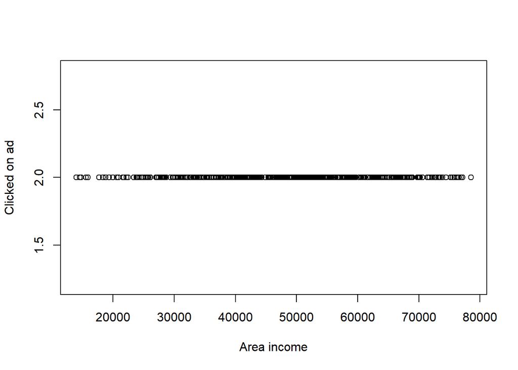

```r
#Plotting area income and clicked on add
area.income <- clicked$Area.Income
clicked.on.ad <- clicked$Clicked.on.Ad
plot(area.income, clicked.on.ad, xlab='Area income', ylab='Clicked on ad')
```

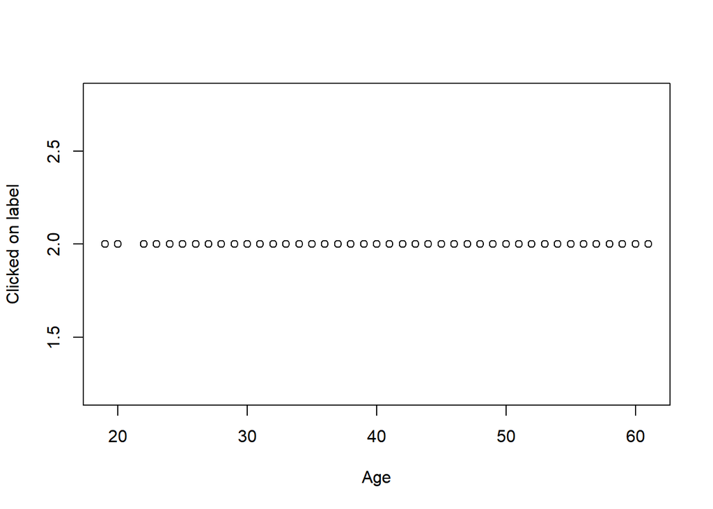

```r
#Plotting scatter plot of age and clicked on ad
age <- clicked$Age
clicked.on.ad <- clicked$Clicked.on.Ad
plot(age, clicked.on.ad, xlab='Age', ylab='Clicked on label')
```

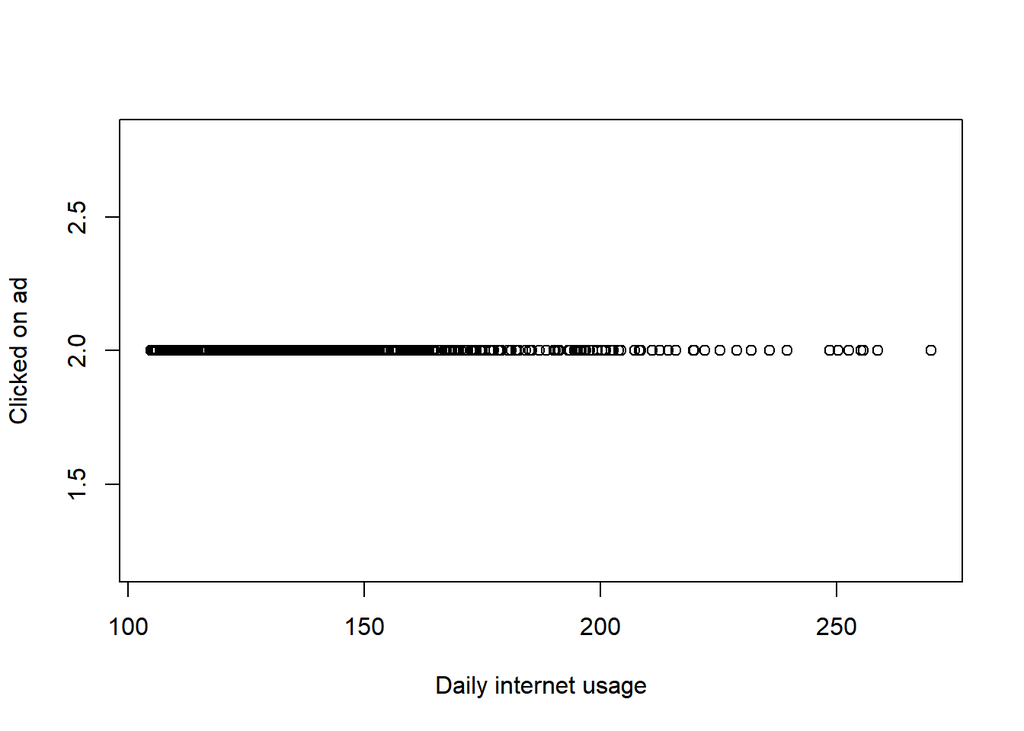

```r
#Plotting scatter plot of daily internet usage and clicked on ad
daily.internet.usage <- clicked$Daily.Internet.Usage
clicked.on.ad <- clicked$Clicked.on.Ad
plot(daily.internet.usage, clicked.on.ad, xlab='Daily internet usage', ylab='Clicked on ad')
```

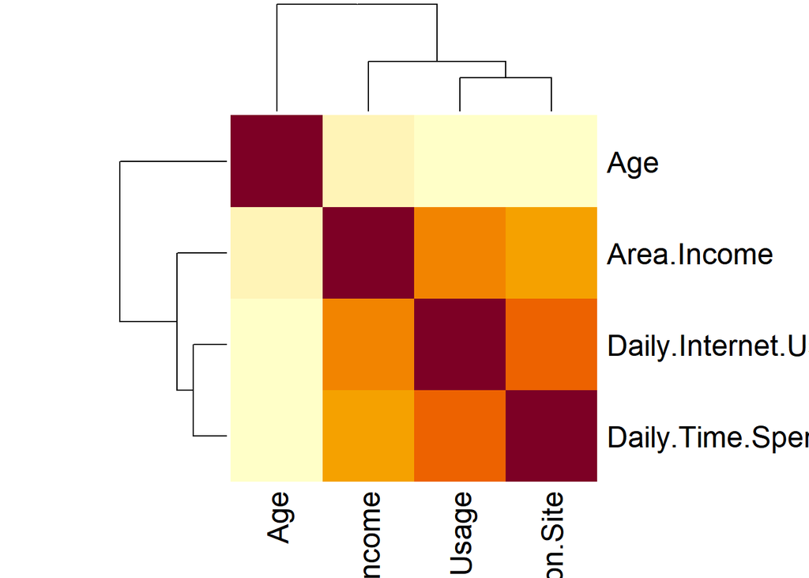

```r
#Plotting a heat map using the correlation matrix
heatmap(x=cor, symm=TRUE)
```

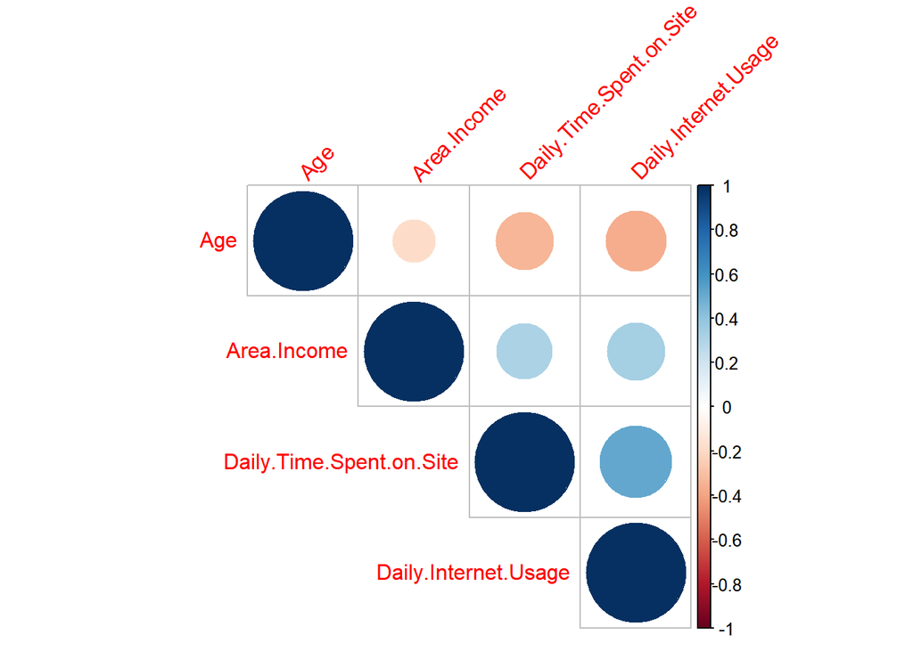

```r
#Plotting a correlogram
library('corrplot')
corrplot(cor, type='upper', order='hclust', tl.color='black', tl.srt=45)
```

### Observations from Bivariate and Multivariate Analysis

- Females clicked more on the ads

*The ad received received most clicks from the month of February

- Most ad clicks were done at 9am
- Australia, Ethiopia and Turkey had the most ad clicks
- The cities of Lake David, Lake James and Lisamouth had the most ad clicks
- Most people that clicked on the ad had spent 75minutes daily on the site.
- Most ad clicks came from people aged, 45, 36 and 38 years.
- Daily internet usage and daily time spent on site are positively correlated.
- Daily time spent on site and Daily Internet usage are negatively correlated to whether an individual clicks on an ad or not.
- There is no strong correlation between male(gender), age, area income and whether an individual clicked on an ad or not.

#7. Modeling

### Feature Engineering

```r
head(advertising)
```

```
##   Daily.Time.Spent.on.Site Age Area.Income Daily.Internet.Usage
## 1                    68.95  35    61833.90               256.09
## 2                    80.23  31    68441.85               193.77
## 3                    69.47  26    59785.94               236.50
## 4                    74.15  29    54806.18               245.89
## 5                    68.37  35    73889.99               225.58
## 6                    59.99  23    59761.56               226.74
##                           Ad.Topic.Line           City Gender    Country
## 1    Cloned 5thgeneration orchestration    Wrightburgh      0    Tunisia
## 2    Monitored national standardization      West Jodi      1      Nauru
## 3      Organic bottom-line service-desk       Davidton      0 San Marino
## 4 Triple-buffered reciprocal time-frame West Terrifurt      1      Italy
## 5         Robust logistical utilization   South Manuel      0    Iceland
## 6       Sharable client-driven software      Jamieberg      1     Norway
##   Clicked.on.Ad Year Month Day Hour
## 1             0 2016    03  27   00
## 2             0 2016    04  04   01
## 3             0 2016    03  13   20
## 4             0 2016    01  10   02
## 5             0 2016    06  03   03
## 6             0 2016    05  19   14
```

```r
#dropping the year, country, city and ad topic line columns

advertising$Ad.Topic.Line <- NULL
advertising$City <- NULL
advertising$Country <- NULL
advertising$Year <- NULL
head(advertising)
```

```
##   Daily.Time.Spent.on.Site Age Area.Income Daily.Internet.Usage Gender
## 1                    68.95  35    61833.90               256.09      0
## 2                    80.23  31    68441.85               193.77      1
## 3                    69.47  26    59785.94               236.50      0
## 4                    74.15  29    54806.18               245.89      1
## 5                    68.37  35    73889.99               225.58      0
## 6                    59.99  23    59761.56               226.74      1
##   Clicked.on.Ad Month Day Hour
## 1             0    03  27   00
## 2             0    04  04   01
## 3             0    03  13   20
## 4             0    01  10   02
## 5             0    06  03   03
## 6             0    05  19   14
```

```r
advertising[,7:9] <- sapply(advertising[,7:9], as.character)
advertising[,7:9] <- sapply(advertising[,7:9], as.numeric)
head(advertising)
```

```
##   Daily.Time.Spent.on.Site Age Area.Income Daily.Internet.Usage Gender
## 1                    68.95  35    61833.90               256.09      0
## 2                    80.23  31    68441.85               193.77      1
## 3                    69.47  26    59785.94               236.50      0
## 4                    74.15  29    54806.18               245.89      1
## 5                    68.37  35    73889.99               225.58      0
## 6                    59.99  23    59761.56               226.74      1
##   Clicked.on.Ad Month Day Hour
## 1             0     3  27    0
## 2             0     4   4    1
## 3             0     3  13   20
## 4             0     1  10    2
## 5             0     6   3    3
## 6             0     5  19   14
```

```r
advertising$Gender <- as.numeric(as.character(advertising$Gender))
head(advertising)
```

```
##   Daily.Time.Spent.on.Site Age Area.Income Daily.Internet.Usage Gender
## 1                    68.95  35    61833.90               256.09      0
## 2                    80.23  31    68441.85               193.77      1
## 3                    69.47  26    59785.94               236.50      0
## 4                    74.15  29    54806.18               245.89      1
## 5                    68.37  35    73889.99               225.58      0
## 6                    59.99  23    59761.56               226.74      1
##   Clicked.on.Ad Month Day Hour
## 1             0     3  27    0
## 2             0     4   4    1
## 3             0     3  13   20
## 4             0     1  10    2
## 5             0     6   3    3
## 6             0     5  19   14
```

```r
# Normalizing the dataset so that no particular attribute
# has more impact on modeling algorithm than others.
normalize <- function(x){
  return ((x-min(x)) / (max(x)-min(x)))
}
#data$Age<- normalize(data$Age)
advertising$Area.Income<- normalize(advertising$Area.Income)
advertising$Daily.Internet.Usage<- normalize(advertising$Daily.Internet.Usage)
advertising$Daily.Time.Spent.on.Site<- normalize(advertising$Daily.Time.Spent.on.Site)
advertising$Day<- normalize(advertising$Day)
advertising$Gender<- normalize(advertising$Gender)
advertising$Month<- normalize(advertising$Month)
advertising$Hour<- normalize(advertising$Hour)
advertising$Age<- normalize(advertising$Age)
head(advertising)
```

```
##   Daily.Time.Spent.on.Site       Age Area.Income Daily.Internet.Usage Gender
## 1                0.6178820 0.3809524   0.7304725            0.9160310      0
## 2                0.8096209 0.2857143   0.8313752            0.5387456      1
## 3                0.6267211 0.1666667   0.6992003            0.7974331      0
## 4                0.7062723 0.2380952   0.6231599            0.8542802      1
## 5                0.6080231 0.3809524   0.9145678            0.7313234      0
## 6                0.4655788 0.0952381   0.6988280            0.7383460      1
##   Clicked.on.Ad     Month        Day       Hour
## 1             0 0.3333333 0.86666667 0.00000000
## 2             0 0.5000000 0.10000000 0.04347826
## 3             0 0.3333333 0.40000000 0.86956522
## 4             0 0.0000000 0.30000000 0.08695652
## 5             0 0.8333333 0.06666667 0.13043478
## 6             0 0.6666667 0.60000000 0.60869565
```

```r
advertising$Geder <- NULL
head(advertising)
```

```
##   Daily.Time.Spent.on.Site       Age Area.Income Daily.Internet.Usage Gender
## 1                0.6178820 0.3809524   0.7304725            0.9160310      0
## 2                0.8096209 0.2857143   0.8313752            0.5387456      1
## 3                0.6267211 0.1666667   0.6992003            0.7974331      0
## 4                0.7062723 0.2380952   0.6231599            0.8542802      1
## 5                0.6080231 0.3809524   0.9145678            0.7313234      0
## 6                0.4655788 0.0952381   0.6988280            0.7383460      1
##   Clicked.on.Ad     Month        Day       Hour
## 1             0 0.3333333 0.86666667 0.00000000
## 2             0 0.5000000 0.10000000 0.04347826
## 3             0 0.3333333 0.40000000 0.86956522
## 4             0 0.0000000 0.30000000 0.08695652
## 5             0 0.8333333 0.06666667 0.13043478
## 6             0 0.6666667 0.60000000 0.60869565
```

### Decision Trees

```r
#Loading libraries
library(rpart,quietly = TRUE)
library(caret,quietly = TRUE)
```

```r
library(rpart.plot,quietly = TRUE)
library(rattle)
#data splicing
set.seed(123)
train <- sample(1:nrow(advertising),size = ceiling(0.80*nrow(advertising)),replace = FALSE)
# training set
ad_train <- advertising[train,]
# test set
ad_test <- advertising[-train,]
```

```r
#Penalty matrix
penalty.matrix <- matrix(c(0, 1, 10,0), byrow = TRUE, nrow = 2)

#Building our model
tree <- rpart(Clicked.on.Ad ~., data = ad_train, parms=list(loss=penalty.matrix), method = 'class')
tree
```

```
## n= 800
##
## node), split, n, loss, yval, (yprob)
##       * denotes terminal node
##
##  1) root 800 389 1 (0.486250000 0.513750000)
##    2) Daily.Internet.Usage>=0.5662308 319 270 0 (0.915360502 0.084639498)
##      4) Daily.Time.Spent.on.Site>=0.5281319 289  90 0 (0.968858131 0.031141869)
##        8) Area.Income>=0.5787783 238  30 0 (0.987394958 0.012605042)
##         16) Daily.Time.Spent.on.Site>=0.6013089 215  10 0 (0.995348837 0.004651163) *
##         17) Daily.Time.Spent.on.Site< 0.6013089 23  20 0 (0.913043478 0.086956522)
##           34) Daily.Time.Spent.on.Site< 0.5802312 16   0 0 (1.000000000 0.000000000) *
##           35) Daily.Time.Spent.on.Site>=0.5802312 7   5 1 (0.714285714 0.285714286) *
##        9) Area.Income< 0.5787783 51  45 1 (0.882352941 0.117647059)
##         18) Age< 0.202381 19   0 0 (1.000000000 0.000000000) *
##         19) Age>=0.202381 32  26 1 (0.812500000 0.187500000)
##           38) Day>=0.45 17  10 0 (0.941176471 0.058823529) *
##           39) Day< 0.45 15  10 1 (0.666666667 0.333333333) *
##      5) Daily.Time.Spent.on.Site< 0.5281319 30  12 1 (0.400000000 0.600000000) *
##    3) Daily.Internet.Usage< 0.5662308 481  97 1 (0.201663202 0.798336798)
##      6) Daily.Time.Spent.on.Site>=0.7324494 83  65 1 (0.783132530 0.216867470)
##       12) Daily.Internet.Usage>=0.4720002 37   0 0 (1.000000000 0.000000000) *
##       13) Daily.Internet.Usage< 0.4720002 46  28 1 (0.608695652 0.391304348)
##         26) Daily.Internet.Usage>=0.3478932 25  22 1 (0.880000000 0.120000000)
##           52) Month< 0.4166667 13   0 0 (1.000000000 0.000000000) *
##           53) Month>=0.4166667 12   9 1 (0.750000000 0.250000000) *
##         27) Daily.Internet.Usage< 0.3478932 21   6 1 (0.285714286 0.714285714) *
##      7) Daily.Time.Spent.on.Site< 0.7324494 398  32 1 (0.080402010 0.919597990)
##       14) Area.Income>=0.9611263 8   7 1 (0.875000000 0.125000000) *
##       15) Area.Income< 0.9611263 390  25 1 (0.064102564 0.935897436)
##         30) Daily.Time.Spent.on.Site>=0.6013089 50  19 1 (0.380000000 0.620000000)
##           60) Daily.Internet.Usage>=0.4080094 13   0 0 (1.000000000 0.000000000) *
##           61) Daily.Internet.Usage< 0.4080094 37   6 1 (0.162162162 0.837837838) *
##         31) Daily.Time.Spent.on.Site< 0.6013089 340   6 1 (0.017647059 0.982352941) *
```

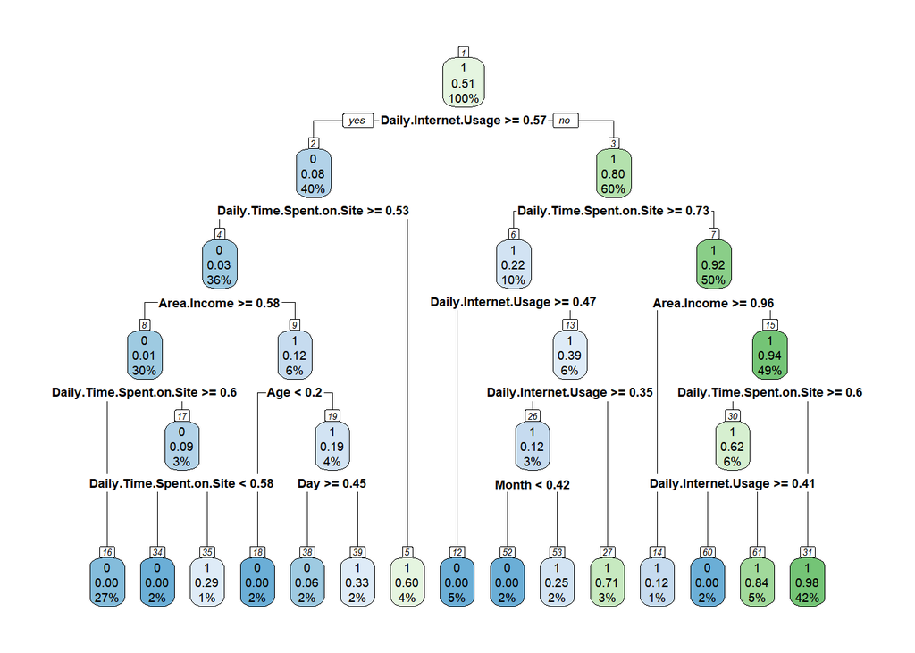

```r
#visualizing the tree
rpart.plot(tree, nn=TRUE)
```

```r
#making predictions with our model
pred <- predict(object = tree, ad_test[,-6], type = 'class')

#calculating accuracy
t <- table(ad_test$Clicked.on.Ad, pred)
confusionMatrix(t)
```

```
## Confusion Matrix and Statistics
##
##    pred
##      0  1
##   0 91 20
##   1  3 86
##
##                Accuracy : 0.885
##                  95% CI : (0.8325, 0.9257)
##     No Information Rate : 0.53
##     P-Value [Acc > NIR] : < 2.2e-16
##
##                   Kappa : 0.7715
##
##  Mcnemar's Test P-Value : 0.0008492
##
##             Sensitivity : 0.9681
##             Specificity : 0.8113
##          Pos Pred Value : 0.8198
##          Neg Pred Value : 0.9663
##              Prevalence : 0.4700
##          Detection Rate : 0.4550
##    Detection Prevalence : 0.5550
##       Balanced Accuracy : 0.8897
##
##        'Positive' Class : 0
##
```

#8. Challenging the solution

### SVM

```r
library('caret')
intrain <- createDataPartition(y = advertising$Clicked.on.Ad, p= 0.7, list = FALSE)
training <- advertising[intrain,]
testing <- advertising[-intrain,]
dim(training)
```

```
## [1] 700   9
```

```r
dim(testing)
```

```
## [1] 300   9
```

```r
#building our model
#
trctrl <- trainControl(method = "repeatedcv", number = 10, repeats = 3)

svm_Linear <- train(Clicked.on.Ad ~., data = training, method = "svmLinear",
trControl=trctrl,
preProcess = c("center", "scale"),
tuneLength = 10)
svm_Linear
```

```
## Support Vector Machines with Linear Kernel
##
## 700 samples
##   8 predictor
##   2 classes: '0', '1'
##
## Pre-processing: centered (8), scaled (8)
## Resampling: Cross-Validated (10 fold, repeated 3 times)
## Summary of sample sizes: 630, 630, 630, 630, 630, 630, ...
## Resampling results:
##
##   Accuracy   Kappa
##   0.9685714  0.9371429
##
## Tuning parameter 'C' was held constant at a value of 1
```

```r
#making predictions
test_pred <- predict(svm_Linear, newdata = testing)
test_pred
```

```
##   [1] 0 0 0 0 0 1 0 1 0 0 1 0 1 0 0 0 0 1 0 1 1 1 0 1 0 0 1 1 1 1 1 1 0 0 0 1 0
##  [38] 0 1 1 1 0 1 0 1 1 1 1 0 0 0 0 0 0 0 0 0 0 1 1 0 0 0 0 0 1 1 0 1 1 1 1 1 1
##  [75] 0 1 0 1 0 1 1 1 0 0 1 0 1 0 0 0 0 1 0 1 0 0 1 1 1 0 0 0 0 1 0 0 1 0 0 0 0
## [112] 0 0 1 0 0 1 1 1 0 1 0 0 1 1 1 0 1 1 1 1 0 1 1 0 1 0 0 0 0 1 1 0 1 1 0 0 1
## [149] 0 0 1 0 1 1 1 1 1 1 1 0 0 0 0 0 1 0 1 0 1 0 1 1 1 1 1 1 0 1 0 1 0 0 1 0 0
## [186] 1 1 1 0 1 0 0 0 1 0 0 0 1 1 0 1 1 1 0 0 0 0 1 0 1 1 1 1 0 0 0 0 1 0 0 0 1
## [223] 1 1 1 1 0 1 1 0 0 1 1 0 1 1 1 1 0 0 1 0 0 1 1 1 0 1 1 0 0 0 0 1 0 0 0 0 0
## [260] 0 1 0 1 0 1 1 1 0 1 0 0 0 0 1 1 1 0 0 1 1 0 0 1 1 1 0 0 1 0 0 1 1 1 0 1 0
## [297] 1 1 1 1
## Levels: 0 1
```

```r
#checking accuracy of model
confusionMatrix(table(test_pred, testing$Clicked.on.Ad))
```

```
## Confusion Matrix and Statistics
##
##
## test_pred   0   1
##         0 145   8
##         1   5 142
##
##                Accuracy : 0.9567
##                  95% CI : (0.927, 0.9767)
##     No Information Rate : 0.5
##     P-Value [Acc > NIR] : <2e-16
##
##                   Kappa : 0.9133
##
##  Mcnemar's Test P-Value : 0.5791
##
##             Sensitivity : 0.9667
##             Specificity : 0.9467
##          Pos Pred Value : 0.9477
##          Neg Pred Value : 0.9660
##              Prevalence : 0.5000
##          Detection Rate : 0.4833
##    Detection Prevalence : 0.5100
##       Balanced Accuracy : 0.9567
##
##        'Positive' Class : 0
##
```

```r
#Hyperparameter tuning
grid <- expand.grid(C = c(0,0.01, 0.05, 0.1, 0.25, 0.5, 0.75, 1, 1.25, 1.5, 1.75, 2,5))
svm_Linear_Grid <- train(Clicked.on.Ad ~., data = training, method = "svmLinear",
trControl=trctrl,
preProcess = c("center", "scale"),
tuneGrid = grid,
tuneLength = 10)
svm_Linear_Grid
```

```
## Support Vector Machines with Linear Kernel
##
## 700 samples
##   8 predictor
##   2 classes: '0', '1'
##
## Pre-processing: centered (8), scaled (8)
## Resampling: Cross-Validated (10 fold, repeated 3 times)
## Summary of sample sizes: 630, 630, 630, 630, 630, 630, ...
## Resampling results across tuning parameters:
##
##   C     Accuracy   Kappa
##   0.00        NaN        NaN
##   0.01  0.9633333  0.9266667
##   0.05  0.9680952  0.9361905
##   0.10  0.9714286  0.9428571
##   0.25  0.9685714  0.9371429
##   0.50  0.9676190  0.9352381
##   0.75  0.9661905  0.9323810
##   1.00  0.9657143  0.9314286
##   1.25  0.9661905  0.9323810
##   1.50  0.9666667  0.9333333
##   1.75  0.9666667  0.9333333
##   2.00  0.9676190  0.9352381
##   5.00  0.9680952  0.9361905
##
## Accuracy was used to select the optimal model using the largest value.
## The final value used for the model was C = 0.1.
```

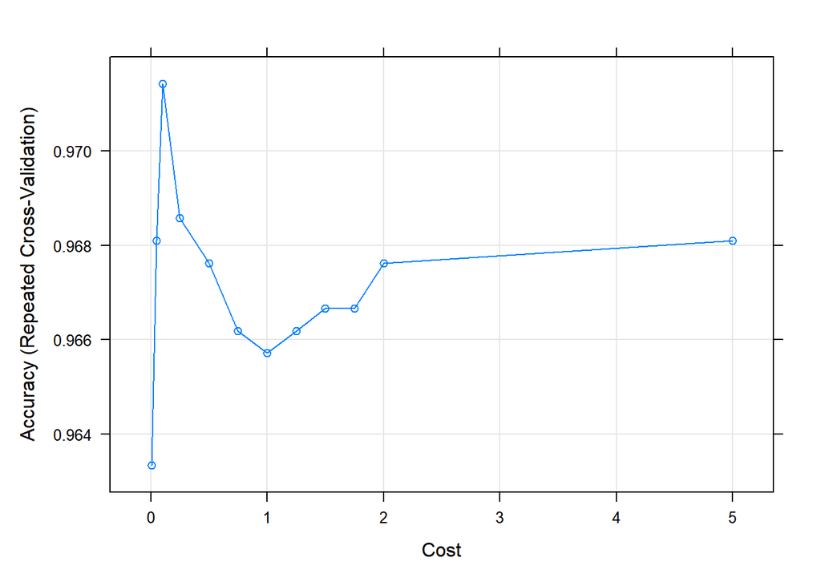

```r
plot(svm_Linear_Grid)
```

```r
#Making predictions with the model after tuning.
test_pred_grid <- predict(svm_Linear_Grid, newdata = testing)
test_pred_grid
```

```
##   [1] 0 0 0 0 0 1 0 1 0 0 1 0 1 0 0 0 0 1 0 1 1 1 0 1 0 0 1 1 1 1 1 1 0 0 0 1 0
##  [38] 0 0 1 1 0 1 0 1 1 1 1 0 0 0 0 0 0 0 0 0 0 1 1 0 0 0 0 0 1 1 0 1 1 1 1 1 1
##  [75] 0 1 0 1 0 1 1 1 0 0 1 0 1 0 0 0 0 1 0 1 0 0 1 1 1 0 0 0 0 1 0 0 1 0 0 0 0
## [112] 0 0 1 0 0 1 1 1 0 1 0 0 1 1 1 0 1 1 1 1 0 1 1 0 1 0 0 0 0 1 1 0 1 1 0 0 1
## [149] 0 0 1 0 1 1 1 1 1 1 1 0 0 0 0 0 1 0 1 0 1 0 1 1 1 1 1 1 0 1 0 1 0 0 1 0 0
## [186] 1 1 1 0 1 0 0 0 1 0 0 0 1 1 0 1 1 1 0 0 0 0 1 0 1 1 1 1 0 0 0 0 1 0 0 0 1
## [223] 1 1 1 1 0 1 1 0 0 1 1 0 1 1 1 1 0 0 1 0 0 1 1 1 0 1 1 0 0 0 0 1 0 0 0 0 0
## [260] 0 1 0 1 0 1 1 1 0 1 0 0 0 0 1 1 1 0 0 1 1 0 0 1 1 1 0 0 1 0 0 1 1 1 0 1 0
## [297] 1 1 1 1
## Levels: 0 1
```

```r
#checking the accuracy
confusionMatrix(table(test_pred_grid, testing$Clicked.on.Ad))
```

```
## Confusion Matrix and Statistics
##
##
## test_pred_grid   0   1
##              0 146   8
##              1   4 142
##
##                Accuracy : 0.96
##                  95% CI : (0.9312, 0.9792)
##     No Information Rate : 0.5
##     P-Value [Acc > NIR] : <2e-16
##
##                   Kappa : 0.92
##
##  Mcnemar's Test P-Value : 0.3865
##
##             Sensitivity : 0.9733
##             Specificity : 0.9467
##          Pos Pred Value : 0.9481
##          Neg Pred Value : 0.9726
##              Prevalence : 0.5000
##          Detection Rate : 0.4867
##    Detection Prevalence : 0.5133
##       Balanced Accuracy : 0.9600
##
##        'Positive' Class : 0
##
```

### Conclusion

- The age and gender do not determine whether an individual clicks on an ad. This is probably because their interests on the internet are different from what the ad is about.
- Daily time spent on a site has a negative correlation on whether an individual clicks on an ad probably because they are already on the site and are aware of what the ad is about.
- The model created using SVM performs better with an accuracy of 95.6% than the one created using decision trees which has an accuracy of 88.5%.
- Hyperparameter tuning doesn’t do much in improving the svm model performance.
- We achieved our metric of success since both our models achieved an accuracy score of above 85%.

### Recommendations

- More resorces should be chanelled towards maximizing the ad clicks gotten at 9am and during the month of February as these are the times with the highest number of ad clicks.
- Ads that are more appealing could be created so as to increase the ad clicks from men.
- We recommend the use of the SVM model in making predictions as it achieved the highest accuracy score of 95.6%.

##9. Follow up questions

###a) Did we have the right data? `Yes we did. Our data set had a good number of variables that helped us study the individuals and determine who was likely to click on an ad..`

###b) Do we need other data to answer our question? `Not necessarily, however further research is needed to help gain deeper insight on the study.`

###c) Did we have the right question? `The question was to create a model that consistently and accurately predicted whether an individual was most likely to click on an ad. We were able to do that by analysing the given dataset.`